# Final Project

Sai Krishna

August 12, 2023

```r
library(forecast)
library(tseries)
library(ggplot2)
```

```r
weather_data <- read.csv("final_data_1970_2023.csv")
```

```r
# Convert datetime column to POSIXct if needed
weather_data$datetime <- as.POSIXct(weather_data$datetime)
range(weather_data$datetime)
```

```
[1] "1970-01-01 CST" "2023-07-31 CDT"
```

```r
#Calculate the average daily temparature
weather_data$avg_temp = (weather_data$tempmax + weather_data$tempmin)/2
```

```r
df.ts <- ts(weather_data, start = c(1970,1), frequency = 365.25)
df.ts_1 <- ts(weather_data, start = c(1970,121.25), frequency = 365.25)
```

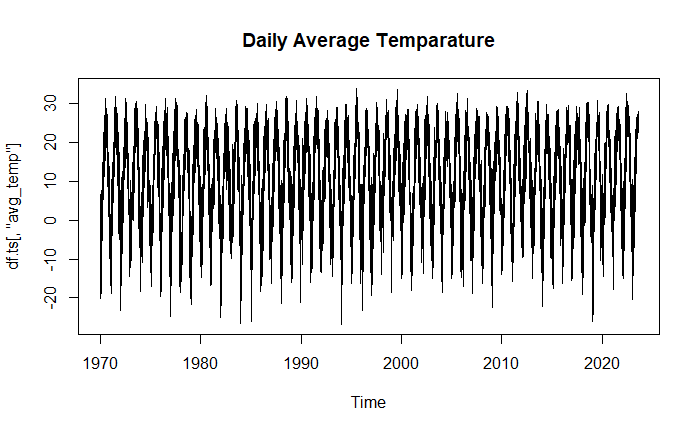

```r
plot(df.ts[,'avg_temp'], main = "Daily Average Temparature")
```

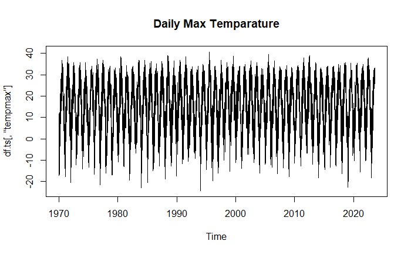

```r
plot(df.ts[,'tempmax'], main = "Daily Max Temparature")
```

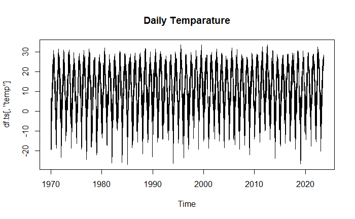

```r
plot(df.ts[,'temp'], main = "Daily Temparature")
```

```
    Ljung-Box test

data:  Residuals
Q* = 4535928, df = 730.5, p-value < 2.2e-16

Model df: 0.   Total lags used: 730.5
```

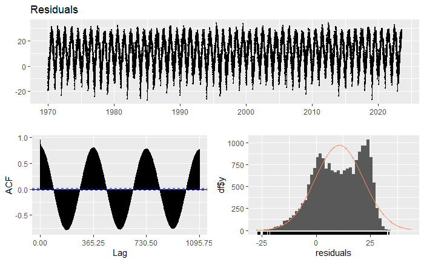

```r
checkresiduals(df.ts[,'temp'])
```

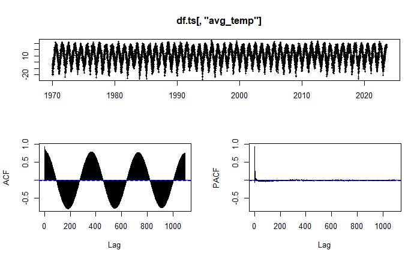

```r
tsdisplay(df.ts[,'avg_temp'])
```

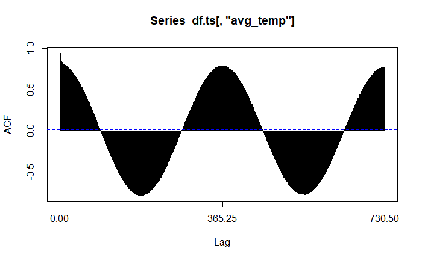

```r
Acf(df.ts[,'avg_temp'])
```

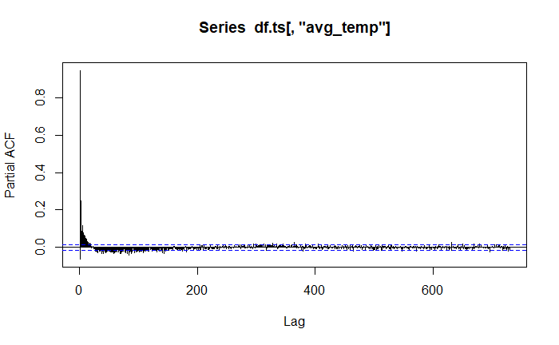

```r
Pacf(df.ts[,'avg_temp'])
```

## The ACF and PACF shows that the data is an auto regressive process. Before applying any transformation, check for the statistical tests confirming the stationarity

```r
kpss.test(df.ts[,'avg_temp'])
```

```
    KPSS Test for Level Stationarity

data:  df.ts[, "avg_temp"]
KPSS Level = 0.32754, Truncation lag parameter = 14, p-value = 0.1
```

```r
adf.test(df.ts[,'avg_temp'])
```

```
    Augmented Dickey-Fuller Test

data:  df.ts[, "avg_temp"]
Dickey-Fuller = -7.9942, Lag order = 26, p-value = 0.01
alternative hypothesis: stationary
```

The statistical tests say that the process is stationary. However, we will check for each factor individually.

## Apply boxcox transformation to see if there is any need for variance stabilization

```r
BoxCox.lambda(df.ts[,'avg_temp'])
```

```
[1] 1.449915
```

BoxCox transformation does show that the stabilization is needed

### Decompose the timeseries data by applying the recommended lambda value

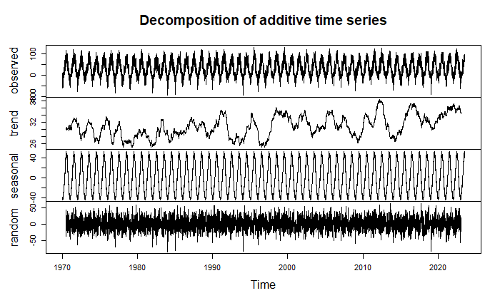

```r
df.ts.boxcox <- BoxCox(df.ts[,'avg_temp'], lambda = 1.5)
plot(decompose(df.ts.boxcox, type = "additive"))
```

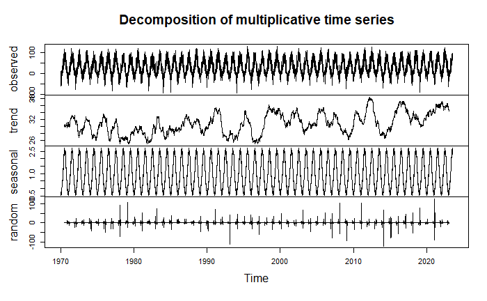

```r
plot(decompose(df.ts.boxcox, type = "multiplicative"))
```

Considering the magnitude of the components, choosing additive time series is more sensible.

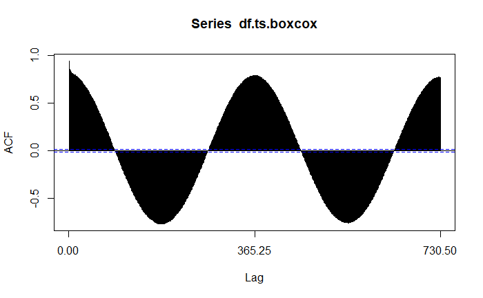

```r
Acf(df.ts.boxcox)
```

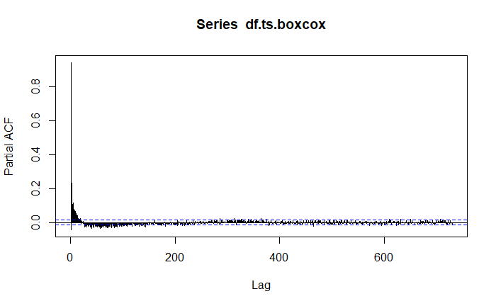

```r
Pacf(df.ts.boxcox)
```

## Applying differencing to remove the seasonality

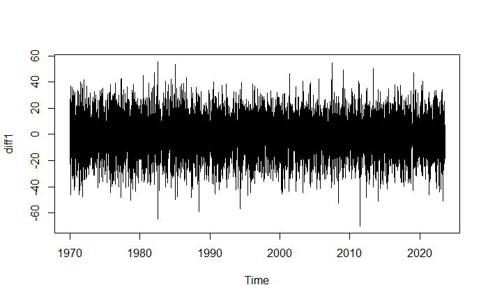

```r
diff1 <- diff(df.ts.boxcox, order = 1)
plot(diff1)
```

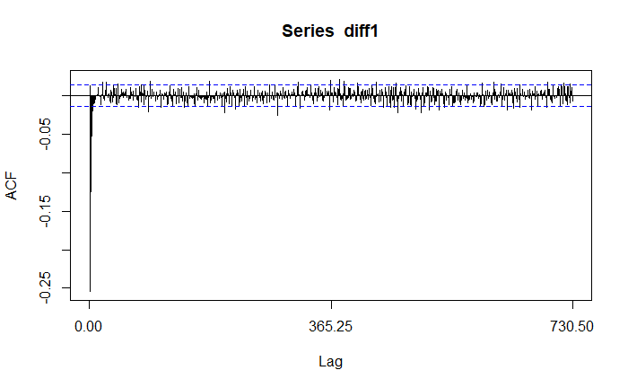

```r
Acf(diff1)
```

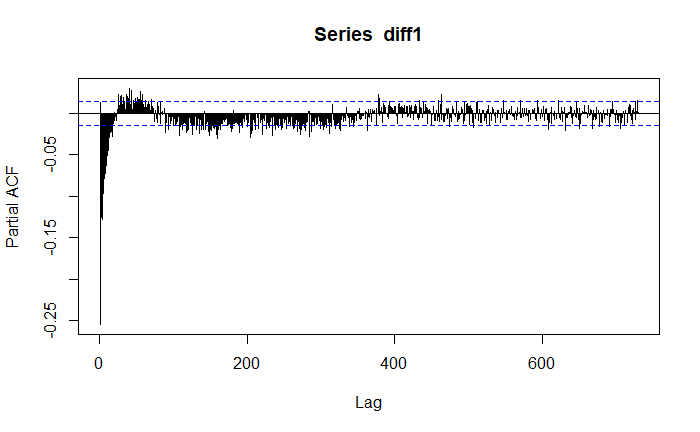

```r
Pacf(diff1)
```

```r
adf.test(diff1)
```

```
    Augmented Dickey-Fuller Test

data:  diff1
Dickey-Fuller = -32.191, Lag order = 26, p-value = 0.01
alternative hypothesis: stationary
```

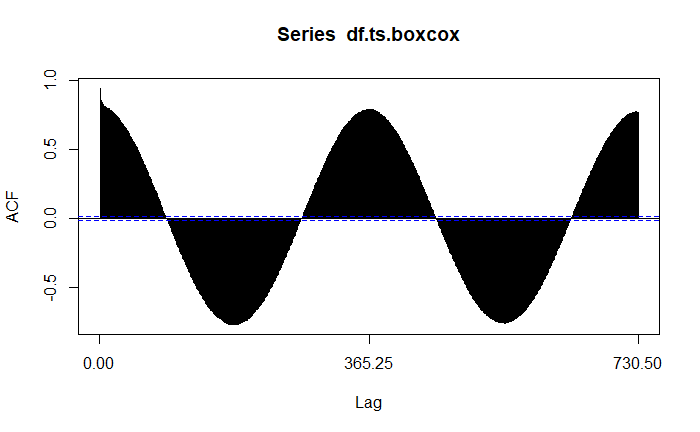

```r
Acf(df.ts.boxcox)
```

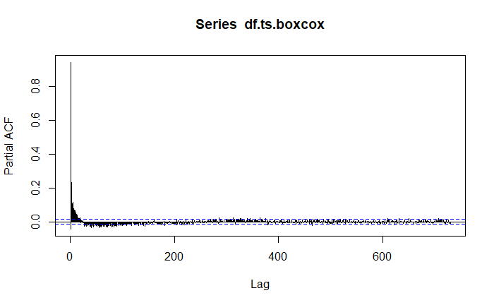

```r
Pacf(df.ts.boxcox)
```

### Split the train and test datasets

```r
# Split the train and test datasets
data.train <- window(df.ts, start = c(1970, 1), end = c(2020, 365.25))

yday_23 <- as.numeric(as.POSIXlt("2023-07-31")$yday)
# data.test <- window(df.ts, start = c(2021, 1), end = c(2023, 7))
data.test <- window(df.ts, start = c(2021, 0), end = c(2023, yday_23))
```

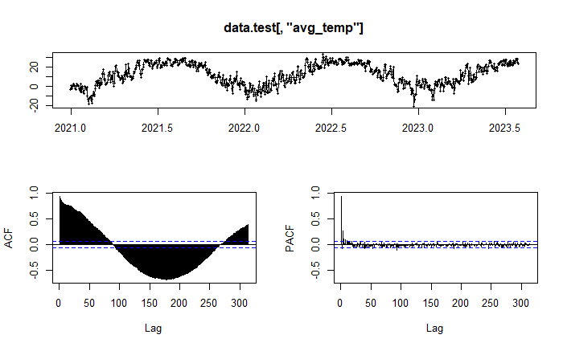

```r
tsdisplay(data.test[,'avg_temp'])
```

## Base model

### Seasonal Naive

```r
fit.snaive <- snaive(data.train[,'avg_temp'], level = c(80,95), lambda = 1.45, h = length(data.test[,'avg_temp']))
summary(fit.snaive)
```

```
Forecast method: Seasonal naive method

Model Information:
Call: snaive(y = data.train[, "avg_temp"], h = length(data.test[, "avg_temp"]),

 Call:     level = c(80, 95), lambda = 1.45)

Residual sd: 19.3735

Error measures:
                     ME     RMSE      MAE MPE MAPE     MASE      ACF1
Training set 0.03284596 6.913779 5.378632 NaN  Inf 1.000702 0.7239257

Forecasts:
```

|  | Point Forecast | Lo 80 | Hi 80 | Lo 95 | Hi 95 |
| --- | --- | --- | --- | --- | --- |
| 2020.9979 | -2.65 | -12.7552281 | 10.889879 | -16.67727681 | 15.043184 |
| 2021.0007 | 0.30 | -11.7995021 | 11.878660 | -15.83499422 | 15.904374 |
| 2021.0034 | 5.95 | -8.6203515 | 14.700653 | -13.11992444 | 18.419031 |
| 2021.0062 | 3.35 | -10.4949860 | 13.117675 | -14.70279020 | 16.999181 |
| 2021.0089 | -0.40 | -11.8991081 | 11.778977 | -15.92230762 | 15.817016 |
| 2021.0116 | 1.05 | -11.5945461 | 12.081423 | -15.65569629 | 16.082415 |
| 2021.0144 | 1.45 | -11.4474713 | 12.225004 | -15.52734247 | 16.208768 |
| 2021.0171 | 1.55 | -11.4073713 | 12.263877 | -15.49239244 | 16.243015 |
| 2021.0198 | -4.95 | -14.0545869 | 9.417326 | -17.83696224 | 13.785616 |
| 2021.0226 | 2.65 | -10.8898792 | 12.755228 | -15.04318365 | 16.677277 |

[output cut: 932 more lines]

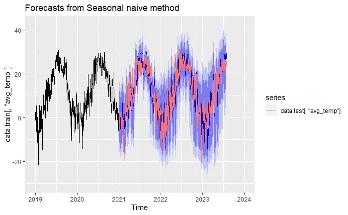

```r
# Create a plot with forecasted and actual values
plot <- autoplot(fit.snaive) + autolayer(data.test[,'avg_temp'])

# Specify the x-axis limits for the last 4 years
last_year <- 2019
plot <- plot + scale_x_continuous(
  limits = c(last_year, 2024),
  breaks = seq(last_year, 2024, by = 1)
)

# Display the plot
print(plot)
```

```r
accuracy(fit.snaive, data.test[,"avg_temp"])
```

```
                     ME     RMSE      MAE MPE MAPE      MASE      ACF1 Theil's U
Training set 0.03284596 6.913779 5.378632 NaN  Inf 1.0007017 0.7239257        NA
Test set     0.15759023 6.171066 4.729034 Inf  Inf 0.8798431 0.6792958         0
```

## Holt Winters might be suitable for the use case since it captures both the trend and seasonality in the data

```r
fit_hw.linear_add.damp <- hw(visitors_ts[,'Arrivals'],seasonal = 'additive', h = 20, damped = TRUE)
plot(fit_hw.linear_add.damp)
```

[output not shown]

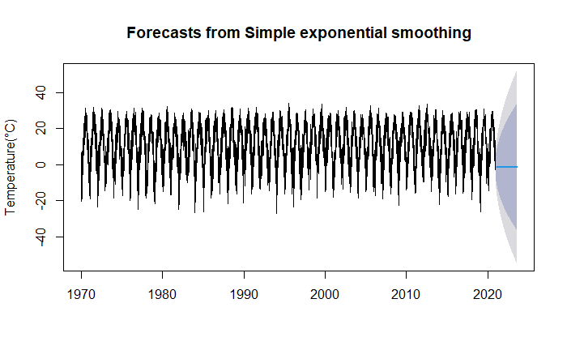

```r
fit.ses <- ses(data.train[,"avg_temp"], h = length(data.test[, "avg_temp"]), alpha = 0.2)
plot(fit.ses, ylab="Temperature(°C)",)
```

```r
fit.hw_add <- hw(data.train[,"avg_temp"],　seasonal="additive",
                 h = length(data.test[,'avg_temp']), frequency = 365, damped = TRUE, alpha = 0.2)
```

[output not shown]

```r
accuracy(fit_hw_add, df_mon_test_ts[,"avgMTemp"])
```

[output not shown]

```r
summary(fit_hw_add)
```

[output not shown]

```r
ls1 <- df_mon_test_ts[,"avgMTemp"]
ls2 <- fit_hw_add$mean
mse = mean((ls1-ls2)^2)
round(mse,2)
rmse = sqrt(mse)
round(rmse,2)
```

[output not shown]

## As previously observed from the ACF and PACF plots, trying out a seasonal ARIMA might give better results

## Seasonal ARIMA using auto.arima

```r
model.sarima <- auto.arima(data.train[,'avg_temp'], lambda = 1.45, trace = TRUE, seasonal = TRUE)
```

[output not shown]

```r
best.arima <- Arima(data.train[,'avg_temp'], order = c(3,0,0),
                    seasonal = list(order=c(0,1,0), period = 365), lambda = 1.45)
summary(best.arima)
```

[output not shown]

```r
source('eacf.R')
```

```r
eacf(data.train[,'avg_temp'])
```

[output not shown]

```r
arima.eacf.202 <- Arima(data.train[,'avg_temp'], order = c(2,0,2),
      seasonal = list(order = c(0,1,0), period = 365.25), lambda = 1.45)
summary(arima.eacf.202)
```

[output not shown]